# 第3回 ミクロ/マクロ②：賃金・貯蓄と統計の基本

## 貯蓄の棒

1. **割る**：G48 に `=E48/F48`  
   G65 まで下へ引く
2. **選ぶ**：D47:D65 を選び  
   Ctrl（Mac は ⌘）で G47:G65 も
3. **描く**：「挿入」→「縦棒/横棒  
   グラフの挿入」→「集合縦棒」
4. **整える**：グラフ タイトルを書き換え  
   外枠を 68 行目より下へ

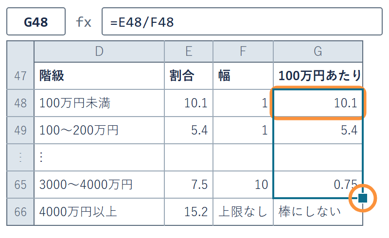

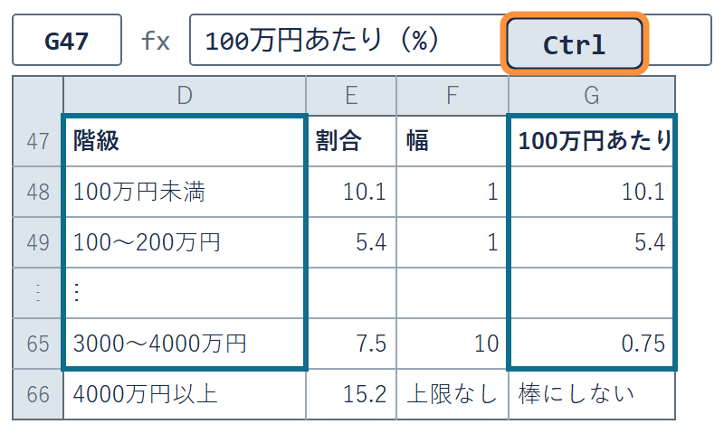

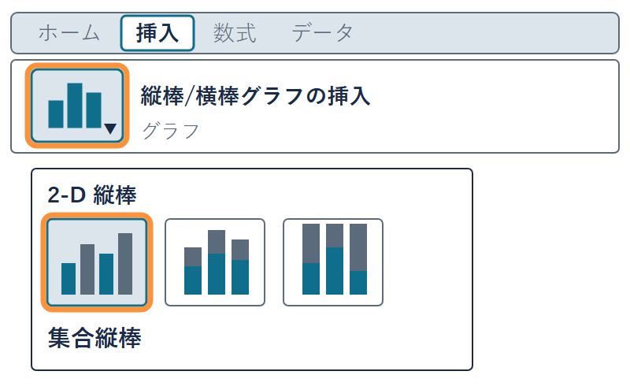

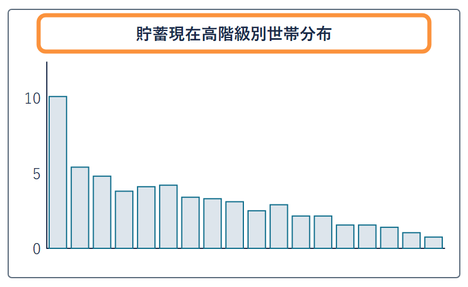

66 行目の 4000 万円以上は選ばない

✋ 動画を止めて STEP 1〜4 を進め、G65 が 0.75 で棒が 18 本なら再生に戻る

## Q&A

Q1 頻度の合計が 9 にならない

入力範囲を確かめる。9 人の **B1:B10** だけで、12・13 行目は入れない

Q2 月給の値を直したのに、頻度が変わらない

ツールの出力は元の値と**つながっていない**。実行し直す

Q3 割合のまま棒にしたら、右のほうに高い棒が出た

幅の広い箱が高く見えている。**幅で割って** 100 万円あたりにそろえる

## 演習 3-3 データ区間の打ち切り

演習 3-3

データ区間の最後を 29 で止めると  
次の級はいくつか

1. **予想**：次の級は何人か（0 人／1 人／2 人）
2. **変える場所**：データ区間だけを I1:I4 にする（入力範囲と「ラベル」はそのまま）
3. **出力先**：M9 にする。「グラフ作成」の印は外す
4. **答えを打つ**：次の級の頻度（N13）を K14 に打つ
5. **戻す**：M9:N13 の表を消す（M1 の出力はそのまま）

✋ 動画を止めて 3 分。K14 に打って M9:N13 を消したら再生に戻る

## 演習 3-3 の答え

演習 3-3 の答え

K14 は 2（30 万円と 34 万円の 2 人）

- **データ区間**：19・24・29 の 3 つ。34 の箱が無い
- **29 の箱まで**：0・3・4 人。ここまでは前と同じ
- **29 より大きい人**：H さんの 30 と I さんの 34 で、次の級に 2 人
- **合計**：0 ＋ 3 ＋ 4 ＋ 2 ＝ 9 人。全員どこかに入る
- **答え欄**：K14 に 2 があり、M9:N13 を消していれば正解

次の級が 0 になるまで、最後の上限を最大の値 34 以上にする

## まとめ

- **階級と度数**：値を箱に分け、箱ごとの人数を数える
- **ヒストグラム**：度数を棒の高さにした図
- **データ区間**：箱の上限。整数なら 24 の箱＝20 以上 25 未満
- **次の級**：最後の上限より大きい値。0 なら区間は足りている
- **貯蓄**：100 万円あたりにそろえると、低い棒が右へ長く続く

次は、この形なら平均と中央値のどちらで語るか

経済データ入門

第3回 — Topic04

分布の形と代表値

その平均は、典型的な世帯か

## この回の道のり

1

平均と中央値

演習 3-1

106 万円とカード

2

散らばり

演習 3-2

80 点を 100 点に

3

ヒストグラム

演習 3-3

29 で止める

4

形と代表値

演習 3-4

3 文で語る

いまここ — その平均は、典型的な世帯か

## 「代表値と散らばり」シートで作る所

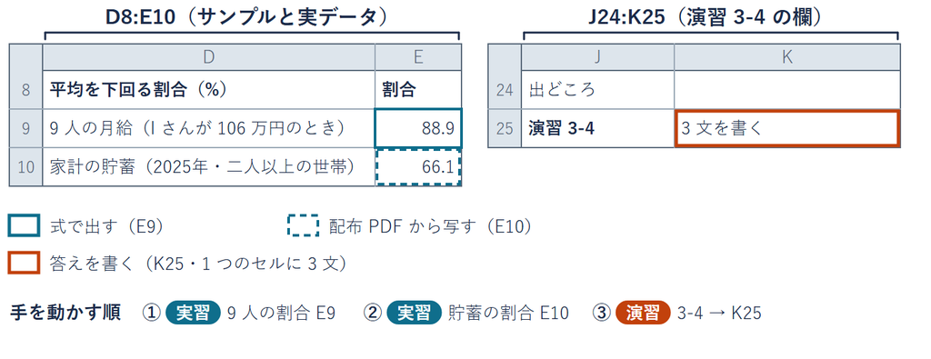

置き場は演習ブック lec3-exercise.xlsx の  
同じシートの D8:E10 と K25

## 1 人だけ 106 万円の 9 人

9 人の平均月給は 34 万円。平均より下の人は何人か

| 社員 | A | B | C | D | E | F | G | H | I |
| --- | --- | --- | --- | --- | --- | --- | --- | --- | --- |
| 月給（万円） | 20 | 22 | 24 | 25 | 25 | 26 | 28 | 30 | 106 |

- **サンプルデータ**：演習 3-1-1 で I さんを 106 万円にした 9 人
- **置き場**：lec3-exercise.xlsx の 2〜10 行目（B10 は 34 に戻してある）
- **平均と中央値**：演習 3-1-1 の答えのとおり、34 と 25
- **シートの B12**：I さんが 34 のままなので、平均は 26 のまま

## 平均の線と 9 人の並び

[figure not shown]

平均より下は 9 人中 8 人。真ん中の E さんは 25 万円

## 右に裾が長い分布の定義

定義

**右に裾が長い**＝大きい側へ、少数の値が長く伸びた分布の形  
このとき**平均 ＞ 中央値**（平均は裾の値に引っ張られる）

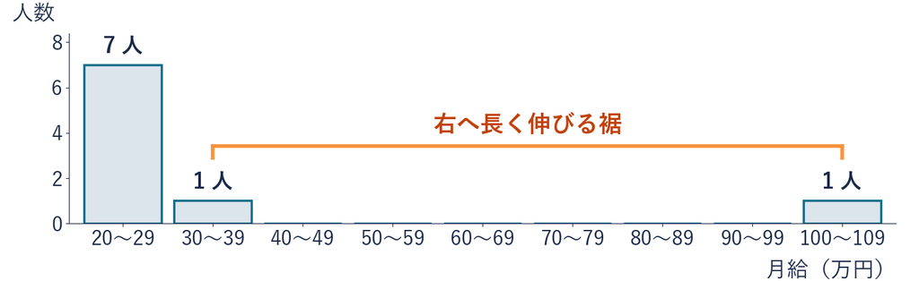

今回は 34 ＞ 25（I さん 1 人の 106 万円が裾をつくる）

## 9 人の平均を下回る割合

1. **割る**：E9 に `=8/9*100`  
   D8・D9 の見出しは入っている
2. **そろえる**：E9 を選び `Ctrl + 1`  
   分類「数値」・桁数 1

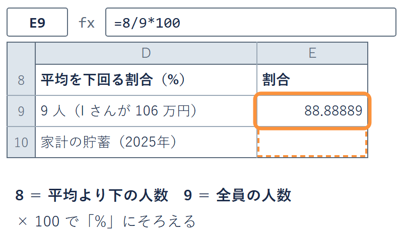

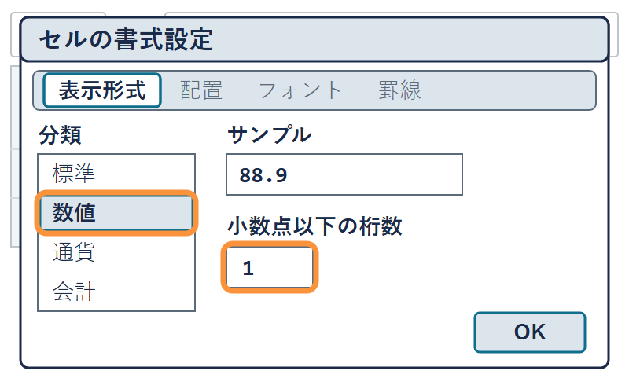

E9 は最初 88.88889 で、小数 1 桁なら 88.9（Mac は `⌘ + 1`）

✋ 動画を止めて STEP 1・2 を進め、E9 が 88.9 なら再生に戻る

## 代表値の選び方

決め

**典型的な 1 人・1 世帯**を語るなら**中央値**  
**全体の総額・1 人あたり**を語るなら**平均**

- **9 人の典型**：中央値 25 万円。8 人は平均の 34 万円に届かない
- **9 人の総額**：34 × 9 人 ＝ 306 万円。平均は総額を人数で割った数
- **ニュースの「平均◯◯万円」**：中央値も探して、並べて読む

## 実データを語る 3 文の型

| STEP | やること | 今回の 9 人 |
| --- | --- | --- |
| 1 数字 | 平均と中央値を、 同じ対象どうしで並べる | 平均 34・中央値 25 |
| 2 理由 | 差が出る理由を、分布の形で述べる | 差 9 は I さんの 106 |
| 3 潰す （否定） | してはいけない読み方を 1 つ否定する | 「ふつう 34」は誤り |

3 文の型＝数字を挙げ、差の理由を述べ、誤った読み方を 1 つ潰す

## 9 人の月給の 3 文

1. **数字**：9 人の月給は、平均では 34 万円だが  
   真ん中の人を表す中央値は 25 万円
2. **理由**：両者に 9 万円の開きがあるのは  
   I さん 1 人の 106 万円が平均を押し上げているため
3. **潰す**：「この 9 人はふつう 34 万円くらいもらう」  
   という読み方は誤り

潰す読み方の反例は、9 人中 8 人が平均より下

## 家計の貯蓄の分布と平均

今度は、トピック 3 で作った貯蓄の棒に平均の線を引く

[figure not shown]

平均 2,059 万円は、2000〜2500 万円の箱の中にある

## 平均を下回る世帯の割合

二人以上の世帯の貯蓄。平均は 2,059 万円  
貯蓄が平均より少ない世帯は、全体のどれくらいか

A  
**3 割**くらい

B  
**半分**くらい

C  
**7 割近く**

9 人のときを思い出して、どれかに決めてから次のページへ

## 平均より下の 66.1% の世帯

[figure not shown]

答えは C。真ん中の世帯は、平均より左の 1,167 万円

## 平均 2,059 万円の読み違い

よくある読み違い

「平均が 2,059 万円なら  
ふつうの世帯も 2,000 万円  
くらい貯めている」

同じ資料の数で読む

66.1% の世帯は平均より下  
真ん中の世帯は 1,167 万円  
平均との差は 892 万円

典型的な世帯を語るなら、中央値の 1,167 万円

## 貯蓄の平均を下回る割合

1. **開く**：配布 PDF の 4 ページ目  
   図Ⅰ-1-3 のすぐ上の本文
2. **写す**：E10 に 66.1  
   % の記号は打たない

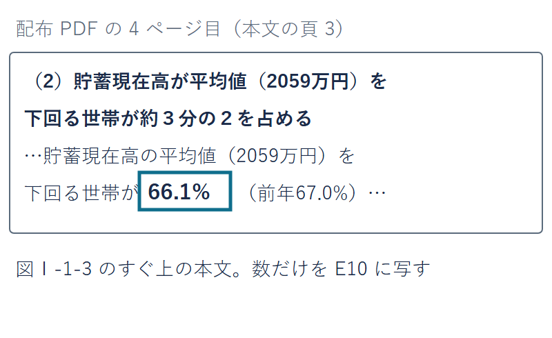

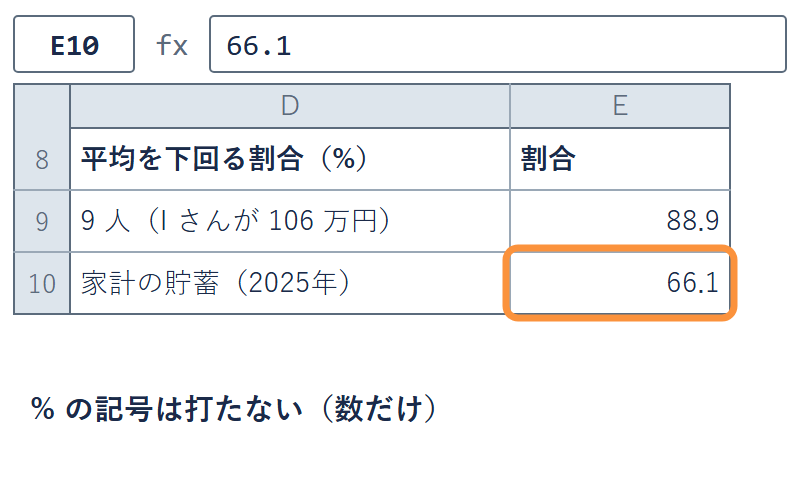

E9 は 88.9 で E10 は 66.1（どちらも平均より下が半分を超える）

✋ 動画を止めて STEP 1・2 を進め、E10 が 66.1 なら再生に戻る

## 演習 3-4 家計の貯蓄の 3 文

演習 3-4

家計の貯蓄を 3 文で語ると、どう書けるか

1. **選ぶ**：平均 E2 と並べる中央値は、E3 と E4 のどちらか  
   （平均 2,059 は貯蓄 0 の世帯も入れた値）
2. **使う数**：差は自分で計算する。潰すときは E10 の割合
3. **書く**：数字・差の理由・潰す読み方の 3 文を続けて書く
4. **書く場所**：J25 の右の K25（この演習も提出する）

✋ 動画を止めて 8 分。K25 に 3 文を書いたら再生に戻る

## 演習 3-4 の答え

演習 3-4 の答え（見本）

中央値は E4 の 1,167（平均と同じ世帯全体）

1. **数字**：日本の二人以上世帯の貯蓄は、平均では 2,059 万円だが  
   典型的な世帯を表す中央値（世帯全体・参考値）は 1,167 万円
2. **理由**：両者に 892 万円の開きがあるのは  
   一部の高貯蓄世帯が平均を押し上げているため
3. **潰す**：「平均的な世帯が 2,000 万円貯めている」  
   という読み方は誤り（根拠：平均より下は 66.1%）

K25 にこの 3 つの部品がそろっていれば正解

## Q&A

Q1 E9 が 88.88889 のまま

`Ctrl + 1`（Mac は `⌘ + 1`）で、小数点以下 1 桁にする

Q2 中央値は 1,264 と 1,167 のどちらで書くか

平均 2,059 は貯蓄 0 の世帯も入れた値。同じ世帯全体の **1,167** と並べる

Q3 平均は使ってはいけないのか

使ってよい。全体の**総額**や 1 世帯あたりを語るときは平均

## まとめ

- **平均と中央値**：平均は大きな値に引っ張られ、中央値は動かない
- **散らばり**：標準偏差は、平均からふつうどれだけ離れているか
- **形**：ヒストグラムで、箱ごとの人数を棒の高さにして見る
- **右に裾が長い**：平均 ＞ 中央値で、平均より下が半分を超える
- **語るとき**：典型なら中央値。数字・差の理由・潰す読み方の 3 文

平均だけでは語れない。散らばりと形まで見て、はじめて語れる